# Tutorial: Dimension Reduction in R

W. Evan Johnson

2026-09-15

## Set up: load these packages!

```r
library(umap)
library(DT)
library(tidyverse)
library(SummarizedExperiment)
library(TBSignatureProfiler)
```

## Data Structures

A data structure is a particular way of organizing data in a computer so that it can be used effectively. The idea is to reduce the space and time complexities of different tasks.

Data structures in R programming are tools for holding multiple values, variables, and sometimes functions

**Please think very carefully about the way you manage and store your data!** This can make your life much easier and make your code and data cleaner and more portable!

### Data Frames

A large proportion of data analysis challenges start with data stored in a data frame. For example, we stored the data for our motivating example in a data frame. You can access this dataset by loading `TBNanostring.rds` object in R:

```r
TBnanostring <- readRDS("TBnanostring.rds")
```

In RStudio we can view the data with the `View` function:

```r
View(TBnanostring)
```

Or in RMarkdown you can use the `datatable` function from the `DT` package:

```r
datatable(TBnanostring)
```

|  | TB_Status | AGAP9 | AIRE | ANKRD22 | APOL1 | APOL6 | ATP1A1 | BATF2 | BCL6 | BLK | C16orf7 | C1QB | C1QC | C4ORF18 | C5 | CCDC14 | CCDC78 | CCR6 | CD1C | CD79A | CD79B | CIRBP | CTSA | CXCR5 | CXorf40B | CYP4F3 | DARS2 | DERA | DUSP3 | … |
| --- | --- | --- | --- | --- | --- | --- | --- | --- | --- | --- | --- | --- | --- | --- | --- | --- | --- | --- | --- | --- | --- | --- | --- | --- | --- | --- | --- | --- | --- | --- |
| Sample_1 | TB | -0.3567952891613851 | -0.2428400750618191 | 1.207905558493485 | 1.555417591919483 | 1.253195633963252 | -1.19773967725765 | 1.267449740074419 | 1.44405564668365 | 0.08830775445314894 | 2.019266536890396 | 0.7516975319176218 | 0.3728128299227613 | -1.044097012784921 | -0.6537817263494731 | -0.6655872996869874 | 0.3941787796749492 | -0.731969022018938 | 0.2519854285556507 | 0.1100454335247583 | 0.02071439218469675 | -0.3212363894966508 | -1.149180848797646 | 0.3352513020122072 | -0.5414855353359561 | 1.274072363654428 | -0.1299396035972255 | -2.397303286864058 | 0.2299788779102083 | … |
| Sample_2 | TB | -0.5855965092374802 | -1.306416297601576 | 1.216041831341325 | 0.5208883402769555 | -0.07293285737957687 | -1.090330219535047 | 0.3970186823102559 | 0.5046354934802626 | -1.668252626535817 | 1.699008243667597 | 1.266415983002439 | 1.397989287308514 | 0.7745526015112829 | 0.5992139442150497 | -1.543550285725023 | 0.004670462482051654 | -1.484418435922324 | 0.3703776259266084 | -2.017855314157253 | -1.50285848270686 | -1.029017144667262 | 1.144979693267663 | -1.591693600854994 | -0.650163550455721 | 0.9066523154368646 | -0.9552105910616149 | 0.5002664813531675 | 1.186088490147909 | … |
| Sample_3 | TB | -0.7078443755887588 | 0.4544570754679451 | 0.1840317405129417 | 0.9494341145965206 | 1.644055869109122 | 0.502818498776224 | 0.5904435779994958 | 0.2033804354046358 | -1.052170149038109 | 0.1905297652957624 | 0.1035590670298391 | 0.002535352876393561 | 1.497504717120949 | 1.111576237536498 | -0.8580099443371357 | -0.675949760725112 | -0.9478361361919522 | -1.131327775946374 | -0.9823028457157846 | -1.345413654355336 | -0.550787253089989 | 1.197782679137242 | -0.9561950288944006 | -0.4921720574098309 | 0.1244443090172449 | -0.7795466235788089 | -0.6559051562414868 | 0.6930788083993142 | … |
| Sample_4 | TB | -1.031494667575215 | -0.600953084668492 | 1.628997686518667 | 2.075581508023125 | 1.823098909982189 | -1.307260034784574 | 1.376982284915563 | 1.847995219384217 | -1.361940589988246 | 2.524736151391167 | 0.755247441115648 | 0.3101495804997122 | 1.163219685390775 | -1.211930639904139 | -1.689793585506124 | 0.5001794710387819 | -1.10819211956498 | -1.193657466264923 | -1.112137911596951 | -1.33186843527569 | -0.7038541523416637 | 0.5308060675652948 | -1.099250316818298 | -0.9543184887761932 | 0.4315414607187606 | -2.026026663896097 | -0.7080736613811327 | 2.244592066682114 | … |
| Sample_5 | TB | 0.9067240290496833 | -0.1348924583178322 | -1.246894792845696 | -1.909669345338767 | -1.884188394186358 | 0.5920268788386729 | -1.565009666862524 | 0.2623956965346229 | 0.820643298328746 | -0.6990454334548679 | -1.083580214103867 | -0.6644456998932498 | 1.952931401028057 | 0.2914324531183866 | 0.8068929732375072 | 0.3842083479338066 | 1.088422222794646 | 1.249115329733536 | 0.9866711547788964 | 0.9104379020429241 | 0.3096601100166029 | -0.1476334293752958 | 0.8238985049492284 | 0.5323003625478224 | -0.004769889750576167 | 0.6436695769010405 | 1.619851589921788 | 0.2219999392611381 | … |
| Sample_6 | TB | -1.83851797105418 | -0.1280090784823144 | 0.8316545568380391 | 1.545006176944255 | 0.7208395835658897 | -1.791034149237936 | 1.348357662074938 | 1.147202275569644 | -1.456526606519168 | 1.041255815744687 | 1.063157431296947 | 0.5869006815956217 | 0.1411222404339071 | 0.4314394118862134 | -1.099506015673339 | -1.109208522979346 | -0.8445763418653442 | -1.513864896772926 | -1.772087484684398 | -1.745419947274584 | -1.684252106610131 | 0.7902316529489498 | -1.834249440392554 | -2.109834739591115 | -0.1924586523473725 | -2.314056444090808 | -0.4059249727368296 | 1.014671428328334 | … |
| Sample_7 | TB | 0.05707858493869713 | -1.069854815292915 | 1.189719488865898 | 0.5402351126887245 | 0.7031789856392341 | -0.3818936938393588 | 0.3827145880386386 | 0.8829995825248439 | -0.7671685890744196 | 0.4830399349631236 | -0.5537144551966539 | -0.2835549663622023 | 0.4692120867406758 | -0.1797230425235556 | -0.5594571787153348 | 0.6181745797269812 | -0.9181663430658387 | -0.4642661301471259 | -0.5040647744700524 | -0.4370386919607227 | 1.016509577140669 | -0.1904821171775223 | -0.4032354212848691 | 0.4023719199114419 | 2.167110090536964 | -0.1801868239153136 | -0.6521957193814021 | -0.6645721100370381 | … |
| Sample_8 | TB | -1.883431240167627 | -0.3126381478393918 | 1.50828543722368 | 0.640879601402786 | 2.013017835850941 | -2.172355556174608 | 1.538902864967792 | 0.1354778929013789 | -1.597201021442571 | 1.001035121012908 | 0.9860346466697851 | 0.5004784541589815 | 2.048798646933404 | 0.415294373849733 | -1.257503350664715 | 0.06130851992982272 | -1.950098254224667 | -0.9548917291379766 | -2.009115587082828 | -2.205184564841673 | -1.395130230563012 | -0.6037633826390437 | -2.0294814108926 | -0.01456281910193487 | 0.3890934324866815 | -1.338975631149127 | -2.174430969936838 | 0.2151384800074111 | … |
| Sample_9 | TB | -1.420386185986475 | 0.515383912267111 | 2.610736305246323 | 2.290270059911697 | 2.319317923810889 | -1.455672628594579 | 2.579743829161462 | 0.6216968649724902 | -1.825897128894175 | 1.524702707602241 | 2.241698148500488 | 2.236351022920394 | 0.6611313274262467 | 1.71147702236411 | -0.8662274369939202 | 0.1874593189327216 | -1.231761445517768 | -2.792921964006282 | -1.568631440608613 | -2.074186261695775 | -1.376791283756899 | 1.411948406363706 | -1.644780614603827 | -1.646583654183484 | 0.009585044330324512 | -1.40905778549676 | -1.238000970587481 | 2.511139673095197 | … |
| Sample_10 | TB | -1.38629357623991 | 0.4353941807468526 | 1.785281524644318 | 1.802817415598585 | 2.251563891720713 | -1.607405208737903 | 1.837433876454194 | 1.030657791301887 | -1.470958653056692 | 1.102376348186373 | 1.202236468820842 | 1.277364549709066 | 0.2999661591271855 | 1.423920466821625 | -1.199193801551537 | -0.1949666172492625 | -1.335260518417128 | -1.314502010055313 | -1.214617477447743 | -1.809972298861618 | -1.88626746616501 | 0.4951357059648722 | -1.568400619543112 | -1.519260006773639 | 0.596428364048616 | -1.774390528190914 | -1.811676935566049 | 1.057072629238347 | … |

[output cut: 169 more lines]

You will notice that the TB status is found in the first column of the data frame, followed by the genes in the subsequent columns. The rows represent each individual patient.

### Advanced Data Structures

There are advanced R data structures, **S3** and **S4** class objects, that can facilitate object orientated programming. One useful example of an S4 class data structure is the **SummarizedExperiment** object.

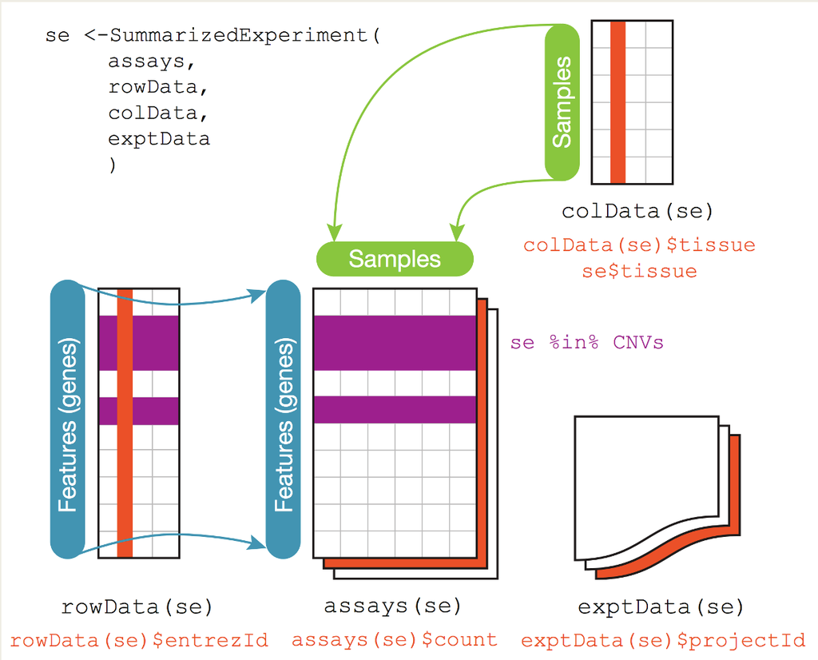

## Dimension Reduction

### PCA Example

Here is the code for applying PCA to the Nanostring dataset:

```r
pca_out <- prcomp(TBnanostring[,-1])
names(pca_out)
```

```
## [1] "sdev"     "rotation" "center"   "scale"    "x"
```

Here is a summary of the explained variation from the PCA:

```r
round(pca_out$sdev^2/sum(pca_out$sdev^2),3)
```

```
##   [1] 0.468 0.073 0.058 0.037 0.033 0.024 0.021 0.018 0.016 0.015 0.013 0.013
##  [13] 0.011 0.010 0.009 0.009 0.008 0.008 0.008 0.007 0.007 0.007 0.006 0.006
##  [25] 0.006 0.006 0.005 0.005 0.005 0.004 0.004 0.004 0.004 0.003 0.003 0.003
##  [37] 0.003 0.003 0.003 0.003 0.002 0.002 0.002 0.002 0.002 0.002 0.002 0.002
##  [49] 0.002 0.002 0.002 0.002 0.001 0.001 0.001 0.001 0.001 0.001 0.001 0.001
##  [61] 0.001 0.001 0.001 0.001 0.001 0.001 0.001 0.001 0.001 0.001 0.001 0.001
##  [73] 0.001 0.001 0.001 0.001 0.000 0.000 0.000 0.000 0.000 0.000 0.000 0.000
##  [85] 0.000 0.000 0.000 0.000 0.000 0.000 0.000 0.000 0.000 0.000 0.000 0.000
##  [97] 0.000 0.000 0.000 0.000 0.000 0.000 0.000 0.000 0.000 0.000 0.000
```

And the cumulative variation explained:

```r
round(cumsum(pca_out$sdev^2)/sum(pca_out$sdev^2),3)
```

```
##   [1] 0.468 0.541 0.599 0.636 0.669 0.694 0.714 0.732 0.747 0.762 0.776 0.788
##  [13] 0.799 0.810 0.819 0.827 0.836 0.844 0.851 0.859 0.866 0.872 0.879 0.885
##  [25] 0.891 0.896 0.902 0.906 0.911 0.915 0.919 0.923 0.927 0.931 0.934 0.937
##  [37] 0.940 0.943 0.946 0.949 0.951 0.953 0.956 0.958 0.960 0.962 0.964 0.966
##  [49] 0.967 0.969 0.971 0.972 0.974 0.975 0.976 0.978 0.979 0.980 0.981 0.982
##  [61] 0.983 0.984 0.985 0.986 0.987 0.988 0.988 0.989 0.990 0.990 0.991 0.992
##  [73] 0.992 0.993 0.993 0.994 0.994 0.995 0.995 0.995 0.996 0.996 0.997 0.997
##  [85] 0.997 0.997 0.998 0.998 0.998 0.998 0.998 0.999 0.999 0.999 0.999 0.999
##  [97] 0.999 0.999 1.000 1.000 1.000 1.000 1.000 1.000 1.000 1.000 1.000
```

Now we will make a dataframe with the PCs for later use!

```r
pca_reduction <- as.data.frame(pca_out$x)
pca_reduction$Condition <- as.factor(TBnanostring$TB_Status)
datatable(pca_reduction)
```

|  | PC1 | PC2 | PC3 | PC4 | PC5 | PC6 | PC7 | PC8 | PC9 | PC10 | PC11 | PC12 | PC13 | PC14 | PC15 | PC16 | PC17 | PC18 | PC19 | PC20 | PC21 | PC22 | PC23 | PC24 | PC25 | PC26 | PC27 | PC28 | PC29 | … |
| --- | --- | --- | --- | --- | --- | --- | --- | --- | --- | --- | --- | --- | --- | --- | --- | --- | --- | --- | --- | --- | --- | --- | --- | --- | --- | --- | --- | --- | --- | --- |
| Sample_1 | -6.217285619912235 | -2.605100122476887 | 1.314995599651241 | -2.222912510120156 | -3.847034204410477 | -3.492482769047263 | -1.710302669240497 | 0.2753538581286486 | -1.813496555108059 | -1.200325429882492 | -0.8808990186810188 | -0.1219053266185675 | -1.582552611013437 | 0.04242755309371542 | -0.7944259158658109 | -1.307819791080606 | -0.5852399567130555 | -0.2913746772345089 | 0.2555178440371068 | 0.4704749235748157 | -0.1439851627875093 | 1.264339838302801 | -1.422892653307124 | -1.165335326219947 | 0.5820134485479109 | -0.3570631620858955 | -0.2162548809175789 | 0.01696140221975795 | -0.1581733782386747 | … |
| Sample_2 | -7.327294251186228 | 3.764234360237172 | -4.968004401929249 | -3.042055621513061 | 0.653265362739976 | 1.503497099757084 | -0.0220517783732817 | -1.356162603441429 | -1.228226578953739 | -1.621593441188546 | 2.206824620735722 | -0.3617561682352567 | 1.22930903148784 | 0.1943927225103861 | 0.456244265636514 | 0.1943418826641857 | 0.298438256087333 | -1.640513759189812 | 0.2175982110323754 | -0.6195920755189992 | -0.5348246604542912 | 0.2708144398327904 | -0.05671070764381446 | -0.5231468963824258 | 0.4391513684270868 | 0.7453528273226954 | 1.353052809694473 | -1.227958471348606 | -0.6628706887075728 | … |
| Sample_3 | -5.375213295990322 | -0.8862508482409736 | 2.241298160038889 | 0.505757534274132 | 2.43278384976374 | -0.1030506481417786 | 1.333842541984344 | -1.894695361759204 | 0.533271897907925 | -0.286568686197602 | 1.823151976887359 | -0.6482705353870546 | -0.5404989184463739 | -1.054640200454538 | -0.7577158439739947 | -0.155829444399522 | 0.7835539346058102 | 1.315466919007759 | -0.6664121322868027 | -0.04494433481058322 | -0.6285763405954409 | 0.8332180834019663 | 0.2939728077350711 | -0.249392309307725 | -0.6654080805899276 | 0.6149917950920574 | -0.2557928344093394 | 0.6309408067401234 | -0.7221634080399858 | … |
| Sample_4 | -11.22400568483464 | 1.329128520222891 | 1.098614164850789 | -2.651950669799342 | -1.112211279400198 | -1.333861976759642 | 0.6005941682138675 | -2.529877123050236 | -1.559959337759631 | 0.5903462931099832 | 0.5527820512095041 | 1.594194889362788 | -1.035454026685189 | -0.8959283020847176 | -0.5882698608649322 | -0.3284223481933758 | 0.2213610925902208 | -0.1237248065915062 | 1.657702768204405 | -0.5400600916871906 | -1.021158550523766 | 0.6795280119532499 | -0.620835236760112 | -0.09750841916064383 | -0.2849688929662881 | 0.2438346205317073 | -0.8954776158702427 | 0.03134943456673537 | -0.4473950460410582 | … |
| Sample_5 | 6.667676591112093 | 3.466185794877574 | -2.027080167283331 | -0.5332913146353364 | 2.557410601173761 | 2.088370679933784 | 1.852993629889535 | 0.453496587473624 | -1.520068144294312 | -0.5151266443808912 | -1.458404813820253 | -2.244486748868971 | 1.014578189887548 | -0.7561009648581655 | 1.169728308902739 | -0.600484906665797 | 0.05053959149620287 | -1.029775788746968 | -0.7231368025192769 | -0.01721701313978025 | -0.1656120110466035 | -0.8353166573891502 | 0.6968177362575784 | 0.08935576179747079 | 0.3301111678739276 | -0.610104783055403 | 0.6641380850424161 | 1.424166712762265 | -0.6206860223444679 | … |
| Sample_6 | -12.6852641655278 | 0.9622367093930643 | -0.6557163374027271 | -0.8505910171108615 | -1.68600060756583 | -0.6764981074211189 | 0.8939391326844555 | 1.967163937693477 | -1.35374917036851 | 2.174956259492704 | 0.744894586884365 | 0.7784962295588769 | -0.8714860609901892 | -1.828129300968337 | 1.357658819698905 | 0.4937324347293457 | -0.1422525783195808 | -1.787279764503487 | -0.01331502750206497 | -0.3698552455284448 | -0.5662953498264115 | -0.09320847600808775 | -0.7996701365393591 | -0.1930695654776413 | -0.3794634854082641 | 0.4709059907311491 | 0.2766861308814644 | 0.8041554950667584 | -0.922816688616346 | … |
| Sample_7 | -1.595124648329725 | 2.568821878267677 | 1.931115058443753 | -0.8881759238466216 | -0.8912067100758612 | -3.184834517755508 | -2.505894207190934 | -1.347029489532844 | -2.929248857311407 | -1.508784717505921 | 0.7995237313954044 | -0.9447058858403381 | 0.7440789705884984 | -0.9034313194709076 | 0.3948835540814009 | -1.321574545412347 | -0.6961857753900481 | -0.1497336970346439 | 0.1916004715655668 | -0.8051956734353192 | -0.2320660183772545 | -0.03888477597435258 | 0.5424119596214639 | -0.5914674835285005 | 0.3342711775302303 | -1.419124163237218 | 1.046647549059853 | 0.1163881506762201 | -0.8007482902795875 | … |
| Sample_8 | -11.46816500281864 | -0.1225153032497423 | 0.7901441729136143 | -1.193895277294539 | 0.3852000673404182 | -1.651022572441891 | -2.190072072127604 | 1.833283071510128 | -0.4645989980222086 | -0.143999867417681 | -0.8696763000595983 | -2.229355415103987 | -0.7223757762579657 | -0.7364175526706959 | 0.6149501928174437 | -3.192591617291779 | -1.261051495240995 | 1.069849215755266 | -1.429882877461464 | -1.529446201840663 | 0.8430643350369224 | -1.411870968297924 | 0.00984800534591104 | -1.138686673874707 | -0.3357704082605922 | 0.07548985303859208 | 0.3822947943594749 | -0.7749946413904009 | 0.1073706934067399 | … |
| Sample_9 | -14.77318128466628 | -1.890561247487708 | 2.884409065914804 | 1.63642332841659 | 2.724324943348443 | -0.8709224193425202 | -1.429777309941266 | -2.152552593316761 | -1.111852445217052 | 0.5239373204144825 | -0.972908365547714 | 3.02633022229736 | 1.29202127754111 | 1.722137410608376 | 0.8494534378048655 | -0.5750536904037739 | -0.57804524816635 | 0.005753324518478664 | 0.1122788922806594 | -0.1729004091584151 | 1.60817277496988 | 0.08260466578644943 | 0.8807108524239012 | 0.1235228444202029 | -0.3932031735473908 | 1.461259037195108 | -2.001513377844452 | -0.3310719201309119 | -0.183259238693781 | … |
| Sample_10 | -11.99951568902558 | -2.226594772258919 | 4.057302920271993 | -1.035967981399325 | -2.130191820935343 | -1.919577720368342 | 0.7168834034670141 | 1.141585099233709 | -0.5140738487376163 | 2.120873142590133 | 1.495517831312241 | 0.4060626598319396 | 0.08985129218650827 | -0.3340843460817793 | -1.60171112481362 | 0.9074865254491618 | -0.6099218745655632 | 0.8589824906557931 | -0.2312643075770045 | -0.3688979021938117 | 0.9310998386401393 | -0.2662870207188572 | 0.5762254232711692 | -0.1705978545355715 | -0.4325555748215056 | 0.1169876695854575 | 1.196118782181585 | 1.035896698767881 | 0.2469918199500905 | … |

[output cut: 169 more lines]